# Risk Factor Analysis

## Outcome Variable

**Outcome Variable:** ever_stunted

## Predictor Variables

**Intervention Variable:** mhtcm

**Adjustment Set:**

unadjusted

## Stratifying Variables

The analysis was stratified on these variable(s):

- agecat
- studyid

The following strata were considered:

- agecat: 12 months, studyid: ki1000304b-SAS-CompFeed
- agecat: 12 months, studyid: ki1000304b-SAS-FoodSuppl
- agecat: 12 months, studyid: ki1017093-NIH-Birth
- agecat: 12 months, studyid: ki1017093c-NIH-Crypto
- agecat: 12 months, studyid: ki1066203-TanzaniaChild2
- agecat: 12 months, studyid: ki1101329-Keneba
- agecat: 12 months, studyid: ki1112895-Guatemala BSC
- agecat: 12 months, studyid: ki1112895-iLiNS-Zinc
- agecat: 12 months, studyid: ki1119695-PROBIT
- agecat: 12 months, studyid: ki1126311-ZVITAMBO
- agecat: 12 months, studyid: ki1135781-COHORTS
- agecat: 12 months, studyid: ki1148112-LCNI-5
- agecat: 12 months, studyid: kiGH5241-JiVitA-3
- agecat: 18 months, studyid: ki1000304b-SAS-CompFeed
- agecat: 18 months, studyid: ki1000304b-SAS-FoodSuppl
- agecat: 18 months, studyid: ki1017093-NIH-Birth
- agecat: 18 months, studyid: ki1017093c-NIH-Crypto
- agecat: 18 months, studyid: ki1066203-TanzaniaChild2
- agecat: 18 months, studyid: ki1101329-Keneba
- agecat: 18 months, studyid: ki1112895-Guatemala BSC
- agecat: 18 months, studyid: ki1112895-iLiNS-Zinc
- agecat: 18 months, studyid: ki1119695-PROBIT
- agecat: 18 months, studyid: ki1126311-ZVITAMBO
- agecat: 18 months, studyid: ki1135781-COHORTS
- agecat: 18 months, studyid: ki1148112-LCNI-5
- agecat: 18 months, studyid: kiGH5241-JiVitA-3
- agecat: 24 months, studyid: ki1000304b-SAS-CompFeed
- agecat: 24 months, studyid: ki1000304b-SAS-FoodSuppl
- agecat: 24 months, studyid: ki1017093-NIH-Birth
- agecat: 24 months, studyid: ki1017093c-NIH-Crypto
- agecat: 24 months, studyid: ki1066203-TanzaniaChild2
- agecat: 24 months, studyid: ki1101329-Keneba
- agecat: 24 months, studyid: ki1112895-iLiNS-Zinc
- agecat: 24 months, studyid: ki1119695-PROBIT
- agecat: 24 months, studyid: ki1126311-ZVITAMBO
- agecat: 24 months, studyid: ki1135781-COHORTS
- agecat: 24 months, studyid: ki1148112-LCNI-5
- agecat: 24 months, studyid: kiGH5241-JiVitA-3
- agecat: 3 months, studyid: ki1000304b-SAS-CompFeed
- agecat: 3 months, studyid: ki1017093-NIH-Birth
- agecat: 3 months, studyid: ki1017093c-NIH-Crypto
- agecat: 3 months, studyid: ki1066203-TanzaniaChild2
- agecat: 3 months, studyid: ki1101329-Keneba
- agecat: 3 months, studyid: ki1119695-PROBIT
- agecat: 3 months, studyid: ki1126311-ZVITAMBO
- agecat: 3 months, studyid: ki1135781-COHORTS
- agecat: 3 months, studyid: kiGH5241-JiVitA-3
- agecat: 6 months, studyid: ki1000304b-SAS-CompFeed
- agecat: 6 months, studyid: ki1000304b-SAS-FoodSuppl
- agecat: 6 months, studyid: ki1017093-NIH-Birth
- agecat: 6 months, studyid: ki1017093c-NIH-Crypto
- agecat: 6 months, studyid: ki1066203-TanzaniaChild2
- agecat: 6 months, studyid: ki1101329-Keneba
- agecat: 6 months, studyid: ki1112895-Guatemala BSC
- agecat: 6 months, studyid: ki1119695-PROBIT
- agecat: 6 months, studyid: ki1126311-ZVITAMBO
- agecat: 6 months, studyid: ki1135781-COHORTS
- agecat: 6 months, studyid: ki1148112-LCNI-5
- agecat: 6 months, studyid: kiGH5241-JiVitA-3

## Methods Detail

# Results Detail

## Results Plots

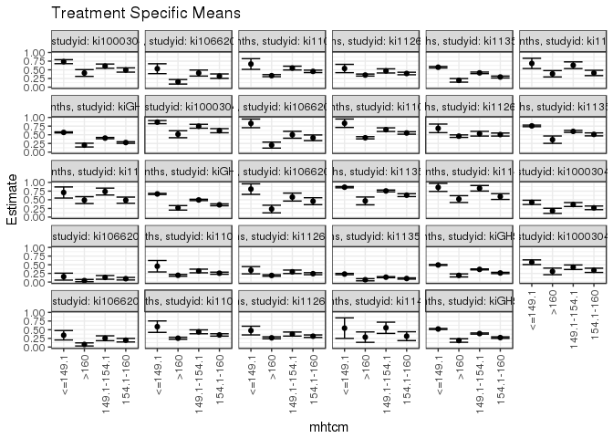

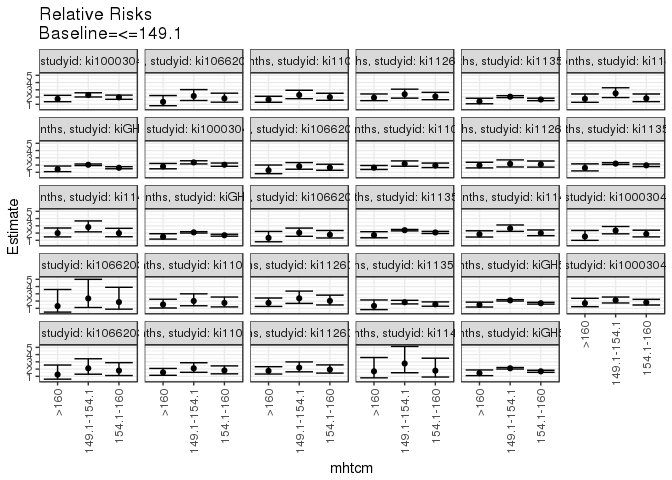

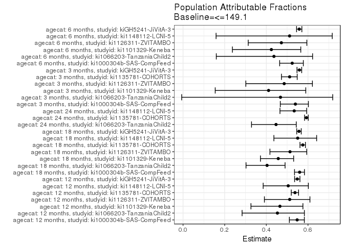

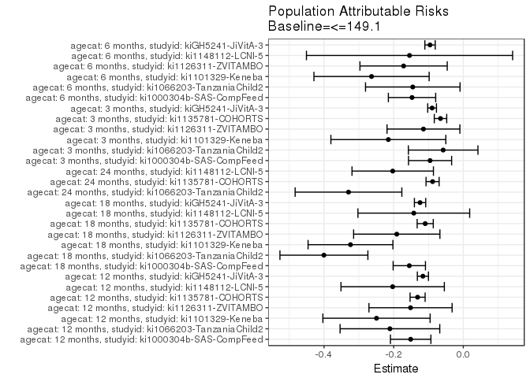

## Data Summary

| agecat | studyid | A | n | nA | nAY0 | nAY1 |
| --- | --- | --- | --- | --- | --- | --- |
| 12 months | ki1000304b-SAS-CompFeed | <=149.1 | 828 | 226 | 60 | 166 |
| 12 months | ki1000304b-SAS-CompFeed | >160 | 828 | 98 | 58 | 40 |
| 12 months | ki1000304b-SAS-CompFeed | 149.1-154.1 | 828 | 249 | 98 | 151 |
| 12 months | ki1000304b-SAS-CompFeed | 154.1-160 | 828 | 255 | 129 | 126 |
| 12 months | ki1000304b-SAS-FoodSuppl | <=149.1 | 98 | 44 | 3 | 41 |
| 12 months | ki1000304b-SAS-FoodSuppl | >160 | 98 | 1 | 0 | 1 |
| 12 months | ki1000304b-SAS-FoodSuppl | 149.1-154.1 | 98 | 35 | 4 | 31 |
| 12 months | ki1000304b-SAS-FoodSuppl | 154.1-160 | 98 | 18 | 8 | 10 |
| 12 months | ki1017093-NIH-Birth | <=149.1 | 541 | 266 | 101 | 165 |
| 12 months | ki1017093-NIH-Birth | >160 | 541 | 17 | 16 | 1 |
| 12 months | ki1017093-NIH-Birth | 149.1-154.1 | 541 | 165 | 87 | 78 |
| 12 months | ki1017093-NIH-Birth | 154.1-160 | 541 | 93 | 61 | 32 |
| 12 months | ki1017093c-NIH-Crypto | <=149.1 | 729 | 303 | 156 | 147 |
| 12 months | ki1017093c-NIH-Crypto | >160 | 729 | 21 | 19 | 2 |
| 12 months | ki1017093c-NIH-Crypto | 149.1-154.1 | 729 | 264 | 174 | 90 |
| 12 months | ki1017093c-NIH-Crypto | 154.1-160 | 729 | 141 | 103 | 38 |
| 12 months | ki1066203-TanzaniaChild2 | <=149.1 | 492 | 47 | 22 | 25 |
| 12 months | ki1066203-TanzaniaChild2 | >160 | 492 | 117 | 99 | 18 |
| 12 months | ki1066203-TanzaniaChild2 | 149.1-154.1 | 492 | 123 | 73 | 50 |
| 12 months | ki1066203-TanzaniaChild2 | 154.1-160 | 492 | 205 | 140 | 65 |
| 12 months | ki1101329-Keneba | <=149.1 | 2099 | 36 | 12 | 24 |
| 12 months | ki1101329-Keneba | >160 | 2099 | 942 | 630 | 312 |
| 12 months | ki1101329-Keneba | 149.1-154.1 | 2099 | 320 | 144 | 176 |
| 12 months | ki1101329-Keneba | 154.1-160 | 2099 | 801 | 437 | 364 |
| 12 months | ki1112895-Guatemala BSC | <=149.1 | 66 | 33 | 14 | 19 |
| 12 months | ki1112895-Guatemala BSC | >160 | 66 | 3 | 3 | 0 |
| 12 months | ki1112895-Guatemala BSC | 149.1-154.1 | 66 | 22 | 13 | 9 |
| 12 months | ki1112895-Guatemala BSC | 154.1-160 | 66 | 8 | 6 | 2 |
| 12 months | ki1112895-iLiNS-Zinc | <=149.1 | 778 | 7 | 2 | 5 |
| 12 months | ki1112895-iLiNS-Zinc | >160 | 778 | 526 | 442 | 84 |

[output cut: 230 more lines]

## Results Table

### Parameter: TSM

| agecat | studyid | intervention_level | baseline_level | estimate | ci_lower | ci_upper |
| --- | --- | --- | --- | --- | --- | --- |
| 12 months | ki1000304b-SAS-CompFeed | <=149.1 | NA | 0.7345133 | 0.6769060 | 0.7921206 |
| 12 months | ki1000304b-SAS-CompFeed | >160 | NA | 0.4081633 | 0.3107955 | 0.5055311 |
| 12 months | ki1000304b-SAS-CompFeed | 149.1-154.1 | NA | 0.6064257 | 0.5457083 | 0.6671431 |
| 12 months | ki1000304b-SAS-CompFeed | 154.1-160 | NA | 0.4941176 | 0.4327160 | 0.5555193 |
| 12 months | ki1066203-TanzaniaChild2 | <=149.1 | NA | 0.5319149 | 0.3891161 | 0.6747137 |
| 12 months | ki1066203-TanzaniaChild2 | >160 | NA | 0.1538462 | 0.0884029 | 0.2192894 |
| 12 months | ki1066203-TanzaniaChild2 | 149.1-154.1 | NA | 0.4065041 | 0.3196123 | 0.4933958 |
| 12 months | ki1066203-TanzaniaChild2 | 154.1-160 | NA | 0.3170732 | 0.2533085 | 0.3808378 |
| 12 months | ki1101329-Keneba | <=149.1 | NA | 0.6666667 | 0.5126407 | 0.8206927 |
| 12 months | ki1101329-Keneba | >160 | NA | 0.3312102 | 0.3011479 | 0.3612725 |
| 12 months | ki1101329-Keneba | 149.1-154.1 | NA | 0.5500000 | 0.4954790 | 0.6045210 |
| 12 months | ki1101329-Keneba | 154.1-160 | NA | 0.4544320 | 0.4199419 | 0.4889220 |
| 12 months | ki1126311-ZVITAMBO | <=149.1 | NA | 0.5373134 | 0.4178946 | 0.6567322 |
| 12 months | ki1126311-ZVITAMBO | >160 | NA | 0.3485881 | 0.3194372 | 0.3777390 |
| 12 months | ki1126311-ZVITAMBO | 149.1-154.1 | NA | 0.4684015 | 0.4087560 | 0.5280470 |
| 12 months | ki1126311-ZVITAMBO | 154.1-160 | NA | 0.3938115 | 0.3578891 | 0.4297340 |
| 12 months | ki1135781-COHORTS | <=149.1 | NA | 0.5744888 | 0.5531049 | 0.5958727 |
| 12 months | ki1135781-COHORTS | >160 | NA | 0.1955556 | 0.1437254 | 0.2473857 |
| 12 months | ki1135781-COHORTS | 149.1-154.1 | NA | 0.4120879 | 0.3894724 | 0.4347034 |
| 12 months | ki1135781-COHORTS | 154.1-160 | NA | 0.2920269 | 0.2644030 | 0.3196508 |
| 12 months | ki1148112-LCNI-5 | <=149.1 | NA | 0.6842105 | 0.5362342 | 0.8321868 |
| 12 months | ki1148112-LCNI-5 | >160 | NA | 0.3853211 | 0.2938440 | 0.4767982 |
| 12 months | ki1148112-LCNI-5 | 149.1-154.1 | NA | 0.6315789 | 0.5344576 | 0.7287003 |
| 12 months | ki1148112-LCNI-5 | 154.1-160 | NA | 0.4088050 | 0.3322956 | 0.4853145 |
| 12 months | kiGH5241-JiVitA-3 | <=149.1 | NA | 0.5679727 | 0.5522281 | 0.5837172 |
| 12 months | kiGH5241-JiVitA-3 | >160 | NA | 0.2018779 | 0.1479687 | 0.2557872 |
| 12 months | kiGH5241-JiVitA-3 | 149.1-154.1 | NA | 0.4048193 | 0.3869685 | 0.4226700 |
| 12 months | kiGH5241-JiVitA-3 | 154.1-160 | NA | 0.2762238 | 0.2530478 | 0.2993998 |
| 18 months | ki1000304b-SAS-CompFeed | <=149.1 | NA | 0.8651163 | 0.8194267 | 0.9108059 |
| 18 months | ki1000304b-SAS-CompFeed | >160 | NA | 0.5157895 | 0.4152327 | 0.6163462 |

[output cut: 86 more lines]

### Parameter: E(Y)

| agecat | studyid | intervention_level | baseline_level | estimate | ci_lower | ci_upper |
| --- | --- | --- | --- | --- | --- | --- |
| 12 months | ki1000304b-SAS-CompFeed | NA | NA | 0.5833333 | 0.5757190 | 0.5909477 |
| 12 months | ki1066203-TanzaniaChild2 | NA | NA | 0.3211382 | 0.3111592 | 0.3311173 |
| 12 months | ki1101329-Keneba | NA | NA | 0.4173416 | 0.4136104 | 0.4210728 |
| 12 months | ki1126311-ZVITAMBO | NA | NA | 0.3857281 | 0.3836483 | 0.3878079 |
| 12 months | ki1135781-COHORTS | NA | NA | 0.4431907 | 0.4398934 | 0.4464879 |
| 12 months | ki1148112-LCNI-5 | NA | NA | 0.4812968 | 0.4697680 | 0.4928255 |
| 12 months | kiGH5241-JiVitA-3 | NA | NA | 0.4519219 | 0.4494036 | 0.4544403 |
| 18 months | ki1000304b-SAS-CompFeed | NA | NA | 0.7100000 | 0.7017947 | 0.7182053 |
| 18 months | ki1066203-TanzaniaChild2 | NA | NA | 0.4281690 | 0.4103127 | 0.4460253 |
| 18 months | ki1101329-Keneba | NA | NA | 0.5092955 | 0.5050458 | 0.5135452 |
| 18 months | ki1126311-ZVITAMBO | NA | NA | 0.4940555 | 0.4917498 | 0.4963611 |
| 18 months | ki1135781-COHORTS | NA | NA | 0.6474045 | 0.6436131 | 0.6511959 |
| 18 months | ki1148112-LCNI-5 | NA | NA | 0.5674847 | 0.5551883 | 0.5797810 |
| 18 months | kiGH5241-JiVitA-3 | NA | NA | 0.5437637 | 0.5408723 | 0.5466551 |
| 24 months | ki1066203-TanzaniaChild2 | NA | NA | 0.4779116 | 0.4571178 | 0.4987055 |
| 24 months | ki1135781-COHORTS | NA | NA | 0.7743436 | 0.7708841 | 0.7778031 |
| 24 months | ki1148112-LCNI-5 | NA | NA | 0.6543909 | 0.6403700 | 0.6684119 |
| 3 months | ki1000304b-SAS-CompFeed | NA | NA | 0.3296337 | 0.3243360 | 0.3349315 |
| 3 months | ki1066203-TanzaniaChild2 | NA | NA | 0.0989933 | 0.0960007 | 0.1019859 |
| 3 months | ki1101329-Keneba | NA | NA | 0.2418650 | 0.2396115 | 0.2441184 |
| 3 months | ki1126311-ZVITAMBO | NA | NA | 0.2272914 | 0.2256112 | 0.2289716 |
| 3 months | ki1135781-COHORTS | NA | NA | 0.1661754 | 0.1646755 | 0.1676752 |
| 3 months | kiGH5241-JiVitA-3 | NA | NA | 0.4035193 | 0.4019403 | 0.4050983 |
| 6 months | ki1000304b-SAS-CompFeed | NA | NA | 0.4255319 | 0.4184009 | 0.4326630 |
| 6 months | ki1066203-TanzaniaChild2 | NA | NA | 0.1952984 | 0.1887535 | 0.2018433 |
| 6 months | ki1101329-Keneba | NA | NA | 0.3246753 | 0.3214126 | 0.3279380 |
| 6 months | ki1126311-ZVITAMBO | NA | NA | 0.3038906 | 0.3017060 | 0.3060752 |
| 6 months | ki1148112-LCNI-5 | NA | NA | 0.3909774 | 0.3704286 | 0.4115263 |
| 6 months | kiGH5241-JiVitA-3 | NA | NA | 0.4255520 | 0.4235523 | 0.4275516 |

### Parameter: RR

| agecat | studyid | intervention_level | baseline_level | estimate | ci_lower | ci_upper |
| --- | --- | --- | --- | --- | --- | --- |
| 12 months | ki1000304b-SAS-CompFeed | >160 | <=149.1 | 1.743147 | 1.3560541 | 2.240738 |
| 12 months | ki1000304b-SAS-CompFeed | 149.1-154.1 | <=149.1 | 2.283286 | 2.0105966 | 2.592960 |
| 12 months | ki1000304b-SAS-CompFeed | 154.1-160 | <=149.1 | 1.959549 | 1.6917589 | 2.269728 |
| 12 months | ki1066203-TanzaniaChild2 | >160 | <=149.1 | 1.335400 | 0.8075252 | 2.208343 |
| 12 months | ki1066203-TanzaniaChild2 | 149.1-154.1 | <=149.1 | 2.147335 | 1.5235794 | 3.026458 |
| 12 months | ki1066203-TanzaniaChild2 | 154.1-160 | <=149.1 | 1.815022 | 1.2977940 | 2.538388 |
| 12 months | ki1101329-Keneba | >160 | <=149.1 | 1.643479 | 1.2822122 | 2.106533 |
| 12 months | ki1101329-Keneba | 149.1-154.1 | <=149.1 | 2.281881 | 1.7746314 | 2.934119 |
| 12 months | ki1101329-Keneba | 154.1-160 | <=149.1 | 1.977133 | 1.5503210 | 2.521449 |
| 12 months | ki1126311-ZVITAMBO | >160 | <=149.1 | 1.913169 | 1.5087741 | 2.425954 |
| 12 months | ki1126311-ZVITAMBO | 149.1-154.1 | <=149.1 | 2.391085 | 1.8507686 | 3.089142 |
| 12 months | ki1126311-ZVITAMBO | 154.1-160 | <=149.1 | 2.081163 | 1.6367043 | 2.646319 |
| 12 months | ki1135781-COHORTS | >160 | <=149.1 | 1.405509 | 1.0754701 | 1.836829 |
| 12 months | ki1135781-COHORTS | 149.1-154.1 | <=149.1 | 2.048919 | 1.9174570 | 2.189394 |
| 12 months | ki1135781-COHORTS | 154.1-160 | <=149.1 | 1.662504 | 1.5018101 | 1.840392 |
| 12 months | ki1148112-LCNI-5 | >160 | <=149.1 | 1.756216 | 1.2738133 | 2.421309 |
| 12 months | ki1148112-LCNI-5 | 149.1-154.1 | <=149.1 | 2.517023 | 1.9303620 | 3.281978 |
| 12 months | ki1148112-LCNI-5 | 154.1-160 | <=149.1 | 1.817541 | 1.3654393 | 2.419334 |
| 12 months | kiGH5241-JiVitA-3 | >160 | <=149.1 | 1.426803 | 1.0908554 | 1.866210 |
| 12 months | kiGH5241-JiVitA-3 | 149.1-154.1 | <=149.1 | 2.039581 | 1.9360683 | 2.148628 |
| 12 months | kiGH5241-JiVitA-3 | 154.1-160 | <=149.1 | 1.626341 | 1.4887981 | 1.776592 |
| 18 months | ki1000304b-SAS-CompFeed | >160 | <=149.1 | 1.815223 | 1.4832334 | 2.221521 |
| 18 months | ki1000304b-SAS-CompFeed | 149.1-154.1 | <=149.1 | 2.367981 | 2.1612462 | 2.594490 |
| 18 months | ki1000304b-SAS-CompFeed | 154.1-160 | <=149.1 | 2.043129 | 1.8299306 | 2.281166 |
| 18 months | ki1066203-TanzaniaChild2 | >160 | <=149.1 | 1.276667 | 0.8131199 | 2.004476 |
| 18 months | ki1066203-TanzaniaChild2 | 149.1-154.1 | <=149.1 | 1.828413 | 1.4251635 | 2.345761 |
| 18 months | ki1066203-TanzaniaChild2 | 154.1-160 | <=149.1 | 1.646251 | 1.2822521 | 2.113581 |
| 18 months | ki1101329-Keneba | >160 | <=149.1 | 1.642454 | 1.3923783 | 1.937444 |
| 18 months | ki1101329-Keneba | 149.1-154.1 | <=149.1 | 2.175248 | 1.8401344 | 2.571391 |
| 18 months | ki1101329-Keneba | 154.1-160 | <=149.1 | 1.938696 | 1.6531493 | 2.273564 |

[output cut: 57 more lines]

### Parameter: PAR

| agecat | studyid | intervention_level | baseline_level | estimate | ci_lower | ci_upper |
| --- | --- | --- | --- | --- | --- | --- |
| 12 months | ki1000304b-SAS-CompFeed | <=149.1 | NA | -0.1511799 | -0.2092883 | -0.0930716 |
| 12 months | ki1066203-TanzaniaChild2 | <=149.1 | NA | -0.2107767 | -0.3539237 | -0.0676297 |
| 12 months | ki1101329-Keneba | <=149.1 | NA | -0.2493251 | -0.4033963 | -0.0952539 |
| 12 months | ki1126311-ZVITAMBO | <=149.1 | NA | -0.1515854 | -0.2710223 | -0.0321485 |
| 12 months | ki1135781-COHORTS | <=149.1 | NA | -0.1312981 | -0.1529347 | -0.1096616 |
| 12 months | ki1148112-LCNI-5 | <=149.1 | NA | -0.2029138 | -0.3513385 | -0.0544890 |
| 12 months | kiGH5241-JiVitA-3 | <=149.1 | NA | -0.1160507 | -0.1319954 | -0.1001060 |
| 18 months | ki1000304b-SAS-CompFeed | <=149.1 | NA | -0.1551163 | -0.2015368 | -0.1086957 |
| 18 months | ki1066203-TanzaniaChild2 | <=149.1 | NA | -0.4004024 | -0.5267065 | -0.2740984 |
| 18 months | ki1101329-Keneba | <=149.1 | NA | -0.3240378 | -0.4458810 | -0.2021947 |
| 18 months | ki1126311-ZVITAMBO | <=149.1 | NA | -0.1911297 | -0.3150668 | -0.0671926 |
| 18 months | ki1135781-COHORTS | <=149.1 | NA | -0.1094120 | -0.1325539 | -0.0862701 |
| 18 months | ki1148112-LCNI-5 | <=149.1 | NA | -0.1421928 | -0.3026959 | 0.0183104 |
| 18 months | kiGH5241-JiVitA-3 | <=149.1 | NA | -0.1242062 | -0.1404737 | -0.1079388 |
| 24 months | ki1066203-TanzaniaChild2 | <=149.1 | NA | -0.3297807 | -0.4829930 | -0.1765684 |
| 24 months | ki1135781-COHORTS | <=149.1 | NA | -0.0882690 | -0.1070804 | -0.0694576 |
| 24 months | ki1148112-LCNI-5 | <=149.1 | NA | -0.2027519 | -0.3196890 | -0.0858149 |
| 3 months | ki1000304b-SAS-CompFeed | <=149.1 | NA | -0.0954675 | -0.1573800 | -0.0335550 |
| 3 months | ki1066203-TanzaniaChild2 | <=149.1 | NA | -0.0578695 | -0.1578076 | 0.0420687 |
| 3 months | ki1101329-Keneba | <=149.1 | NA | -0.2152779 | -0.3803709 | -0.0501848 |
| 3 months | ki1126311-ZVITAMBO | <=149.1 | NA | -0.1144807 | -0.2191059 | -0.0098555 |
| 3 months | ki1135781-COHORTS | <=149.1 | NA | -0.0655206 | -0.0833865 | -0.0476548 |
| 3 months | kiGH5241-JiVitA-3 | <=149.1 | NA | -0.0896868 | -0.1022496 | -0.0771239 |
| 6 months | ki1000304b-SAS-CompFeed | <=149.1 | NA | -0.1472836 | -0.2152543 | -0.0793129 |
| 6 months | ki1066203-TanzaniaChild2 | <=149.1 | NA | -0.1451272 | -0.2808774 | -0.0093769 |
| 6 months | ki1101329-Keneba | <=149.1 | NA | -0.2635600 | -0.4290614 | -0.0980586 |
| 6 months | ki1126311-ZVITAMBO | <=149.1 | NA | -0.1715192 | -0.2968932 | -0.0461452 |
| 6 months | ki1148112-LCNI-5 | <=149.1 | NA | -0.1544771 | -0.4505557 | 0.1416015 |
| 6 months | kiGH5241-JiVitA-3 | <=149.1 | NA | -0.0955461 | -0.1104290 | -0.0806631 |

### Parameter: PAF

| agecat | studyid | intervention_level | baseline_level | estimate | ci_lower | ci_upper |
| --- | --- | --- | --- | --- | --- | --- |
| 12 months | ki1000304b-SAS-CompFeed | <=149.1 | NA | 0.5480468 | 0.5106458 | 0.5825893 |
| 12 months | ki1066203-TanzaniaChild2 | <=149.1 | NA | 0.4532370 | 0.2835779 | 0.5827184 |
| 12 months | ki1101329-Keneba | <=149.1 | NA | 0.4652802 | 0.3261855 | 0.5756617 |
| 12 months | ki1126311-ZVITAMBO | <=149.1 | NA | 0.5122161 | 0.3907738 | 0.6094502 |
| 12 months | ki1135781-COHORTS | <=149.1 | NA | 0.5376588 | 0.5197717 | 0.5548798 |
| 12 months | ki1148112-LCNI-5 | <=149.1 | NA | 0.5051169 | 0.3848187 | 0.6018909 |
| 12 months | kiGH5241-JiVitA-3 | <=149.1 | NA | 0.5487237 | 0.5357817 | 0.5613049 |
| 18 months | ki1000304b-SAS-CompFeed | <=149.1 | NA | 0.5598761 | 0.5354267 | 0.5830387 |
| 18 months | ki1066203-TanzaniaChild2 | <=149.1 | NA | 0.4035475 | 0.3024592 | 0.4899860 |
| 18 months | ki1101329-Keneba | <=149.1 | NA | 0.4572761 | 0.3717353 | 0.5311702 |
| 18 months | ki1126311-ZVITAMBO | <=149.1 | NA | 0.5137605 | 0.4173356 | 0.5942281 |
| 18 months | ki1135781-COHORTS | <=149.1 | NA | 0.5749002 | 0.5616349 | 0.5877640 |
| 18 months | ki1148112-LCNI-5 | <=149.1 | NA | 0.5505081 | 0.4362250 | 0.6416249 |
| 18 months | kiGH5241-JiVitA-3 | <=149.1 | NA | 0.5569418 | 0.5459307 | 0.5676859 |
| 24 months | ki1066203-TanzaniaChild2 | <=149.1 | NA | 0.4466143 | 0.3288704 | 0.5437011 |
| 24 months | ki1135781-COHORTS | <=149.1 | NA | 0.5924830 | 0.5834615 | 0.6013090 |
| 24 months | ki1148112-LCNI-5 | <=149.1 | NA | 0.5339471 | 0.4654497 | 0.5936672 |
| 3 months | ki1000304b-SAS-CompFeed | <=149.1 | NA | 0.5394916 | 0.4671041 | 0.6020461 |
| 3 months | ki1066203-TanzaniaChild2 | <=149.1 | NA | 0.4679843 | -0.0064761 | 0.7187805 |
| 3 months | ki1101329-Keneba | <=149.1 | NA | 0.4108531 | 0.1545211 | 0.5894704 |
| 3 months | ki1126311-ZVITAMBO | <=149.1 | NA | 0.4857459 | 0.3015296 | 0.6213766 |
| 3 months | ki1135781-COHORTS | <=149.1 | NA | 0.5118893 | 0.4726273 | 0.5482282 |
| 3 months | kiGH5241-JiVitA-3 | <=149.1 | NA | 0.5587553 | 0.5473267 | 0.5698953 |
| 6 months | ki1000304b-SAS-CompFeed | <=149.1 | NA | 0.5242571 | 0.4640358 | 0.5777119 |
| 6 months | ki1066203-TanzaniaChild2 | <=149.1 | NA | 0.4365569 | 0.1596856 | 0.6222032 |
| 6 months | ki1101329-Keneba | <=149.1 | NA | 0.4241730 | 0.2369799 | 0.5654417 |
| 6 months | ki1126311-ZVITAMBO | <=149.1 | NA | 0.4722952 | 0.3130148 | 0.5946457 |
| 6 months | ki1148112-LCNI-5 | <=149.1 | NA | 0.5116837 | 0.1586483 | 0.7165837 |
| 6 months | kiGH5241-JiVitA-3 | <=149.1 | NA | 0.5580881 | 0.5452264 | 0.5705861 |